# hw1_part1_usd

## IE 360 Statistical Forecasting and Time Series - HW1

## Eylül Rana Saraç - 2019402126

### Introduction

Time series data are particularly important in the field of financial and economic analysis. This project aims to explore the time series data provided by the Central Bank of the Republic of Turkey (CBRT) and the pattern of correlation and causality between these data.

The analysis will start with the selection of appropriate independent variables for the selected target variables, followed by the visualization and analysis of the data, and then the interpretation of possible relationships. In this stage of the analysis, extensive visualizations and descriptive data analysis techniques will be used. Then, in light of the findings, time series regression models will be constructed to statistically model the relationship between the target variables and the independent variables. These models will support the validity of the analysis by providing statistical evidence such as residual analysis and significance of coefficients. With these time series regression models for each CBRT category, our aim is to demonstrate logical and meaningful relationships between the data.

### Choosen Target Variables

1. TP DK USD A YTL: US Dollar Buying Price

The USD/TRY exchange rate is a critical economic indicator that reflects the interaction between international trade dynamics and domestic financial health. Modeling this exchange rate with relevant independent variables, such as the Russian Ruble exchange rate, provides a deeper understanding of the interactions and economic interdependencies between currencies.

1. TP EFTEMKT2 ADET A01: Number of Payment Messages

This indicator, which shows the level of activity in payment systems, is a measure of liquidity and financial efficiency in the economy. We try to use this data in the context of the rise of the digital economy in particular, by linking it to financial technologies and market dynamics.

1. TP ELEKTUKETIM URT: Daily Electricity Generation (MWh)

Electricity generation is a powerful indicator of industrial activity and societal consumption patterns. By correlating this measure with the Composite Leading Indicators Index and the Fuel and Energy Price Index, we reveal layers of pricing and their impact on foreseeable economic trends.

### Checking the Pairwise Correlation

```python
import pandas as pd

data_path = "C:\\Users\\EylülRanaSaraç\\OneDrive - boun.edu.tr\\Masaüstü\\IE 360\\hw1\\target variables.csv"

df = pd.read_csv(data_path, delimiter=';', decimal=',', na_values=';;')

# save the Date column and delete it from the df
date_series = df['Date']
df = df.drop('Date', axis=1)

for column in df.columns:
    if df[column].dtype == 'object':  # controls the string data type
        df[column] = df[column].str.replace('.', '').str.replace(',', '.').astype(float)

# add the Date column again to the first column
df.insert(0, 'Date', date_series)

# delete the rows with all NaN values
df.dropna(how='all', inplace=True)

df.head()
```

|  | Date | TP DK USD A YTL | TP ELEKTUKETIM URT | TP EFTEMKT2 ADET A01 |
| --- | --- | --- | --- | --- |
| 0 | 2011-10 | 1.83 | NaN | 0.0 |
| 1 | 2011-11 | 1.80 | NaN | 0.0 |
| 2 | 2011-12 | 1.86 | NaN | 0.0 |
| 3 | 2012-01 | 1.84 | NaN | 0.0 |
| 4 | 2012-02 | 1.75 | NaN | 0.0 |

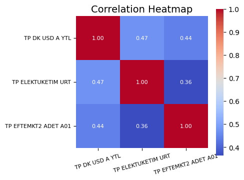

```python
import matplotlib.pyplot as plt
import seaborn as sns

df['Date'] = pd.to_datetime(df['Date'])

# Set the date column as the index
df.set_index('Date', inplace=True)

# Calculate the correlation matrix
correlation_matrix = df.corr()

plt.figure(figsize=(5, 4))

# draw the heatmap
ax = sns.heatmap(correlation_matrix, annot=True, cmap='coolwarm', fmt=".2f",
                 annot_kws={'size': 8}, square=True)

plt.xticks(fontsize=8, rotation=15)
plt.yticks(fontsize=8, rotation=0)
plt.title('Correlation Heatmap', fontsize=14)
plt.tight_layout()

plt.show()
```

### 1. TP DK USD A YTL (USD Buying Level)

#### Discovering the Data

```python
data_path = "C:\\Users\\EylülRanaSaraç\\OneDrive - boun.edu.tr\\Masaüstü\\IE 360\\hw1\\dolar.csv"

df_usd = pd.read_csv(data_path, delimiter=';', decimal=',', na_values=';;')

# save the Date column and delete it from the df
date_dolar = df_usd['Date']
df_usd = df_usd.drop('Date', axis=1)

for column in df_usd.columns:
    if df_usd[column].dtype == 'object':  # controls the string data type
        df_usd[column] = df_usd[column].str.replace('.', '').str.replace(',', '.').astype(float)

# add the Date column again to the first column
df_usd.insert(0, 'date', date_dolar)

# delete the rows with all NaN values
df_usd.dropna(how='all', inplace=True)
```

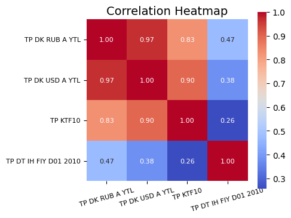

```python
df_usd['date'] = pd.to_datetime(df_usd['date'])

# Set the date column as the index
df_usd.set_index('date', inplace=True)

# Calculate the correlation matrix
correlation_matrix_usd = df_usd.corr()

plt.figure(figsize=(5, 4))

# draw the heatmap
ax = sns.heatmap(correlation_matrix_usd, annot=True, cmap='coolwarm', fmt=".2f",
                 annot_kws={'size': 8}, square=True)

plt.xticks(fontsize=8, rotation=15)
plt.yticks(fontsize=8, rotation=0)
plt.title('Correlation Heatmap', fontsize=14)
plt.tight_layout()

plt.show()
```

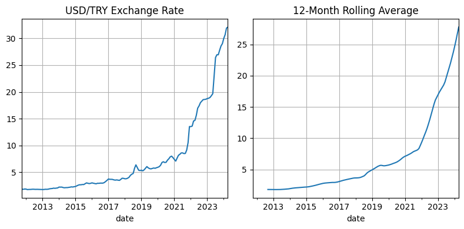

```python
import matplotlib.pyplot as plt

fig, ax = plt.subplots(nrows=1, ncols=2, figsize=(8, 4))

# 1. line plot
df_usd['TP DK USD A YTL'].plot(ax=ax[0])
ax[0].set_title('USD/TRY Exchange Rate')
ax[0].grid(True)

# 2. 12-Month Rolling Average
df_usd['TP DK USD A YTL'].rolling(window=12).mean().plot(ax=ax[1])
ax[1].set_title('12-Month Rolling Average')
ax[1].grid(True)

plt.tight_layout()
plt.show()
```

A rising upward trend is observed from 2020 onwards.

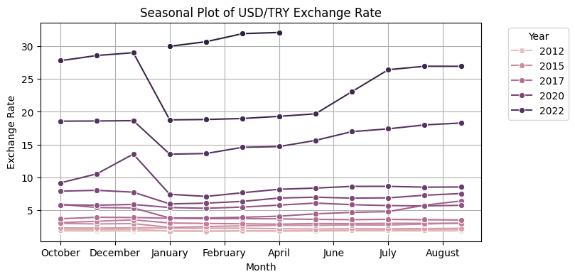

```python
from matplotlib.ticker import MaxNLocator

df_usd['Month'] = df_usd.index.month_name()
df_usd['Year'] = df_usd.index.year

plt.figure(figsize=(8, 4))
sns.lineplot(x="Month", y="TP DK USD A YTL", hue="Year", data=df_usd, marker='o')

plt.title('Seasonal Plot of USD/TRY Exchange Rate')
plt.ylabel('Exchange Rate')
plt.legend(title='Year', bbox_to_anchor=(1.05, 1), loc='upper left')
plt.grid(True)
plt.gca().xaxis.set_major_locator(MaxNLocator(nbins=12))

plt.show()
```

The exchange rate fell in late December and then rose slowly to the same level in the following months.

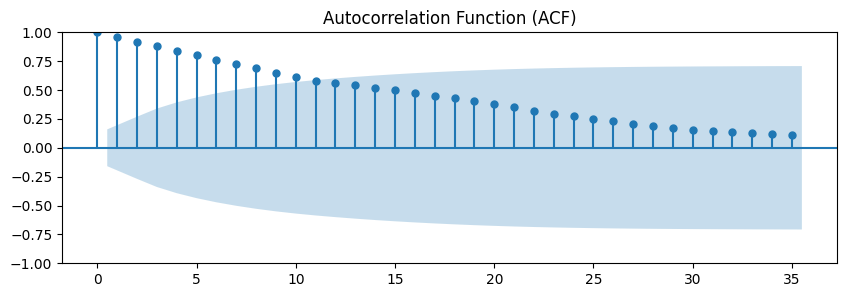

```python
from statsmodels.graphics.tsaplots import plot_acf, plot_pacf

# ACF
plt.figure(figsize=(10, 3))
plot_acf(df_usd['TP DK USD A YTL'], lags=35, ax=plt.gca())
plt.title('Autocorrelation Function (ACF)')

plt.show()
```

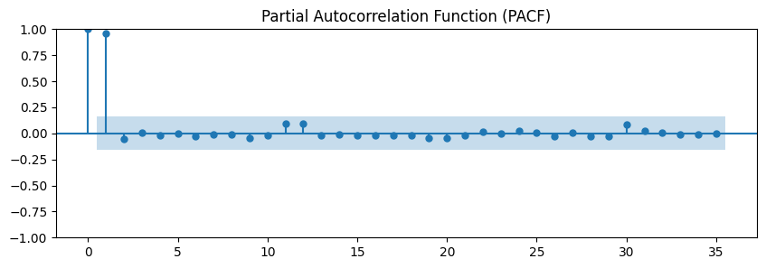

```python
# PACF
plt.figure(figsize=(10, 3))
plot_pacf(df_usd['TP DK USD A YTL'], lags=35, ax=plt.gca())
plt.title('Partial Autocorrelation Function (PACF)')

plt.show()
```

The PACF plot shows significant partial autocorrelations only in the first two lags, suggesting that an AR(1) or AR(2) model may fit the data.

```python
# ADF Test for stationarity

from statsmodels.tsa.stattools import adfuller

series = df_usd['TP DK USD A YTL']

adf_test = adfuller(series, autolag='AIC')

print('ADF Statistic: %f' % adf_test[0])
print('p-value: %f' % adf_test[1])
print('Used lags: %d' % adf_test[2])
print('Number of Observations Used: %d' % adf_test[3])
print('Critical Values:')
for key, value in adf_test[4].items():
    print('\t%s: %.3f' % (key, value))

# If the p-value is less than 0.05, we can assume that the series is stationary.
if adf_test[1] < 0.05:
    print("The series can be assumed to be stationary. There is no unit root.")
else:
    print("The series can be considered non-stationary. A unit root is found.")
```

```
ADF Statistic: 4.364939
p-value: 1.000000
Used lags: 10
Number of Observations Used: 140
Critical Values:
	1%: -3.478
	5%: -2.882
	10%: -2.578
The series can be considered non-stationary. A unit root is found.
```

As we expected, the series is not stationary. Let us stationarize it.

```python
df_usd['diff_TP DK USD A YTL'] = df_usd['TP DK USD A YTL'].diff()

df_usd['diff_TP DK USD A YTL'] = df_usd['diff_TP DK USD A YTL'].dropna()

import numpy as np

df_usd.replace([np.inf, -np.inf], np.nan, inplace=True)

df_usd.dropna(inplace=True)

# Make ADF test again
adf_test = adfuller(df_usd['diff_TP DK USD A YTL'])

print('ADF Statistic: %f' % adf_test[0])
print('p-value: %f' % adf_test[1])

# If the p-value is less than 0.05, we can assume that the series is stationary.
if adf_test[1] < 0.05:
    print("The series can be assumed to be stationary. There is no unit root.")
else:
    print("The series can be considered non-stationary. A unit root is found.")
```

```
ADF Statistic: -3.411758
p-value: 0.010565
The series can be assumed to be stationary. There is no unit root.
```

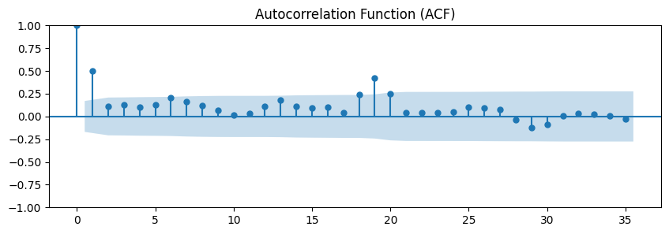

```python
plt.figure(figsize=(10, 3))
plot_acf(df_usd['diff_TP DK USD A YTL'], lags=35, ax=plt.gca())
plt.title('Autocorrelation Function (ACF)')

plt.show()
```

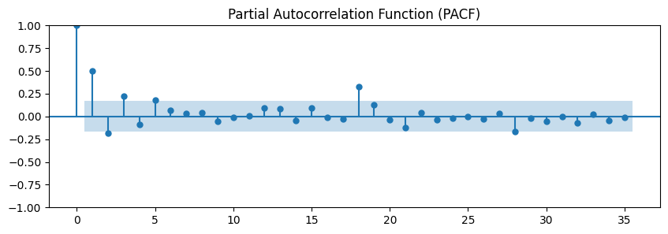

```python
plt.figure(figsize=(10, 3))
plot_pacf(df_usd['diff_TP DK USD A YTL'], lags=35, ax=plt.gca())
plt.title('Partial Autocorrelation Function (PACF)')

plt.show()
```

Based on the ADF test and ACF graph, we can say that the series is stationarized. Now let's build a model. We can make the AR and MA coefficients 1 in the ARIMA model since in the ACF and PACF graphs the first lag is outside of the confidence intervals.

### Introducing an Independent Variable

TP DK RUB A YTL shows high correlation with TP DK USD A TRY -> We can use RUB/TRY in our model for predicting USD/YTL

The correlation between the Russian Ruble (RUB) and the US Dollar (USD) is related to the fact that Russian exports, such as energy resources and raw materials, are usually traded in USD on world markets. This causes the value of the Ruble to depend on global raw material prices and thus on the USD. In addition, Russia's trade balance, political and economic uncertainties, and the policies of both the Bank of Russia and the US Federal Reserve can affect the RUB/USD exchange rate. In this context, using the Ruble in an analysis makes sense to understand global economic influences and policies on the USD.

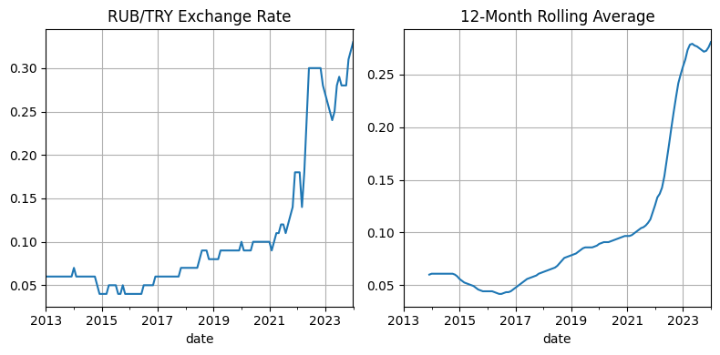

```python
fig, ax = plt.subplots(nrows=1, ncols=2, figsize=(8, 4))

# 1. line plot
df_usd['TP DK RUB A YTL'].plot(ax=ax[0])
ax[0].set_title('RUB/TRY Exchange Rate')
ax[0].grid(True)

# 2. 12-Month Rolling Average
df_usd['TP DK RUB A YTL'].rolling(window=12).mean().plot(ax=ax[1])
ax[1].set_title('12-Month Rolling Average')
ax[1].grid(True)

plt.tight_layout()
plt.show()
```

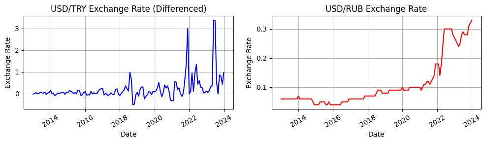

```python
# Comparing USD and RUB data
fig, axes = plt.subplots(nrows=1, ncols=2, figsize=(10, 3))

# 1st subplot
axes[0].plot(df_usd.index, df_usd['diff_TP DK USD A YTL'], label='USD/TRY Exchange Rate', color='blue')
axes[0].set_title('USD/TRY Exchange Rate (Differenced)')
axes[0].set_xlabel('Date')
axes[0].set_ylabel('Exchange Rate')
axes[0].grid(True)

# 2nd subplot
axes[1].plot(df_usd.index, df_usd['TP DK RUB A YTL'], label='USD/RUB Exchange Rate', color='red')
axes[1].set_title('USD/RUB Exchange Rate')
axes[1].set_xlabel('Date')
axes[1].set_ylabel('Exchange Rate')
axes[1].grid(True)

for ax in axes:
    plt.sca(ax)
    plt.xticks(rotation=30)

plt.tight_layout()
plt.show()
```

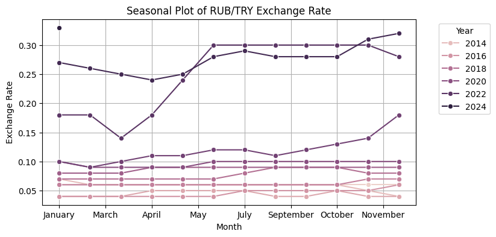

```python
df_usd['Month'] = df_usd.index.month_name()
df_usd['Year'] = df_usd.index.year

plt.figure(figsize=(8, 4))
sns.lineplot(x="Month", y="TP DK RUB A YTL", hue="Year", data=df_usd, marker='o')

plt.title('Seasonal Plot of RUB/TRY Exchange Rate')
plt.ylabel('Exchange Rate')
plt.legend(title='Year', bbox_to_anchor=(1.05, 1), loc='upper left')
plt.grid(True)
plt.gca().xaxis.set_major_locator(MaxNLocator(nbins=12))

plt.show()
```

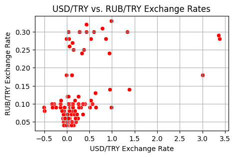

```python
plt.figure(figsize=(5, 3))
sns.scatterplot(x='diff_TP DK USD A YTL', y='TP DK RUB A YTL', data=df_usd, color='red')
plt.title('USD/TRY vs. RUB/TRY Exchange Rates')
plt.xlabel('USD/TRY Exchange Rate')
plt.ylabel('RUB/TRY Exchange Rate')
plt.grid(True)
plt.show()
```

### Linear Regression Model

```
R^2 Score:  0.12330669764704583
Mean Squared Error (MSE): 0.6594990571014462
USD/TRY = -0.03213182826647465 + [1.68321141] * (RUB/TRY)
```

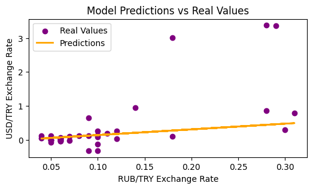

```python
from sklearn.model_selection import train_test_split
from sklearn.linear_model import LinearRegression
from sklearn.metrics import mean_squared_error, r2_score

# indepentent variable
X = df_usd[['TP DK RUB A YTL']].values

# depentent variable
y = df_usd['diff_TP DK USD A YTL'].values

# creating test and train sets
X_train, X_test, y_train, y_test = train_test_split(X, y, test_size=0.3, random_state=0)

# Training the model
model = LinearRegression()
model.fit(X_train, y_train)

# making predictions
y_pred = model.predict(X_test)

# evaluating the model performance
print(f"R^2 Score: ", r2_score(y_test, y_pred))
print("Mean Squared Error (MSE):", mean_squared_error(y_test, y_pred))
print(f"USD/TRY = {model.intercept_} + {model.coef_} * (RUB/TRY) ")

plt.figure(figsize=(6, 3))
plt.scatter(X_test, y_test, color='purple', label='Real Values')
plt.plot(X_test, y_pred, color='orange', linewidth=2, label='Predictions')
plt.title('Model Predictions vs Real Values')
plt.xlabel('RUB/TRY Exchange Rate')
plt.ylabel('USD/TRY Exchange Rate')
plt.legend()
plt.show()
```

R^2 value is too low, the model is quite unsuccessful. Let's try a more advanced model.

### ARIMA Model

Let's start with lag 1 for MA and AR that we read from the ACF and PACF charts.

```python
from statsmodels.tsa.arima.model import ARIMA

model = ARIMA(df_usd['diff_TP DK USD A YTL'], order=(1, 1, 1))

model_fit = model.fit()

print(model_fit.summary())
```

```
                                SARIMAX Results
================================================================================
Dep. Variable:     diff_TP DK USD A YTL   No. Observations:                  133
Model:                   ARIMA(1, 1, 1)   Log Likelihood                 -88.760
Date:                  Fri, 05 Apr 2024   AIC                            183.519
Time:                          22:07:44   BIC                            192.168
Sample:                      01-01-2013   HQIC                           187.034
                           - 01-01-2024
Covariance Type:                    opg
==============================================================================
                 coef    std err          z      P>|z|      [0.025      0.975]
------------------------------------------------------------------------------
ar.L1          0.3987      0.066      6.034      0.000       0.269       0.528
ma.L1         -0.9422      0.044    -21.283      0.000      -1.029      -0.855
sigma2         0.2223      0.009     24.196      0.000       0.204       0.240
===================================================================================
Ljung-Box (L1) (Q):                   1.23   Jarque-Bera (JB):              1610.92
Prob(Q):                              0.27   Prob(JB):                         0.00
Heteroskedasticity (H):             144.83   Skew:                             2.69
Prob(H) (two-sided):                  0.00   Kurtosis:                        19.25
===================================================================================

Warnings:
[1] Covariance matrix calculated using the outer product of gradients (complex-step).
```

With order=(1, 1, 1), AR(1) and MA(1) coefficients have 0.000 p-value, which shows they are statistically significant.

```python
model = ARIMA(df_usd['diff_TP DK USD A YTL'], order=(2, 1, 2))

model_fit = model.fit()

print(model_fit.summary())
```

```
                                SARIMAX Results
================================================================================
Dep. Variable:     diff_TP DK USD A YTL   No. Observations:                  133
Model:                   ARIMA(2, 1, 2)   Log Likelihood                 -79.986
Date:                  Fri, 05 Apr 2024   AIC                            169.972
Time:                          22:07:45   BIC                            184.386
Sample:                      01-01-2013   HQIC                           175.829
                           - 01-01-2024
Covariance Type:                    opg
==============================================================================
                 coef    std err          z      P>|z|      [0.025      0.975]
------------------------------------------------------------------------------
ar.L1         -0.0374      0.187     -0.200      0.842      -0.404       0.329
ar.L2         -0.0936      0.171     -0.546      0.585      -0.429       0.242
ma.L1         -0.3180      0.182     -1.752      0.080      -0.674       0.038
ma.L2         -0.5585      0.211     -2.646      0.008      -0.972      -0.145
sigma2         0.1941      0.007     27.217      0.000       0.180       0.208
===================================================================================
Ljung-Box (L1) (Q):                   0.03   Jarque-Bera (JB):              2632.88
Prob(Q):                              0.86   Prob(JB):                         0.00
Heteroskedasticity (H):              90.61   Skew:                             3.20
Prob(H) (two-sided):                  0.00   Kurtosis:                        23.92
===================================================================================

Warnings:
[1] Covariance matrix calculated using the outer product of gradients (complex-step).
```

In this ARIMA model with order=(2, 1, 2); The AR terms are not significant, only one of the MA terms is significant. The JB statistic is very high (2632.88) and the p-value is 0.00, indicating that the residuals deviate significantly from a normal distribution (very high kurtosis and skewness values). So this is not a good model.

```python
model = ARIMA(df_usd['diff_TP DK USD A YTL'], order=(2, 1, 1))

model_fit = model.fit()

print(model_fit.summary())
```

```
                                SARIMAX Results
================================================================================
Dep. Variable:     diff_TP DK USD A YTL   No. Observations:                  133
Model:                   ARIMA(2, 1, 1)   Log Likelihood                 -82.959
Date:                  Fri, 05 Apr 2024   AIC                            173.918
Time:                          22:07:45   BIC                            185.449
Sample:                      01-01-2013   HQIC                           178.603
                           - 01-01-2024
Covariance Type:                    opg
==============================================================================
                 coef    std err          z      P>|z|      [0.025      0.975]
------------------------------------------------------------------------------
ar.L1          0.4774      0.060      7.904      0.000       0.359       0.596
ar.L2         -0.3012      0.071     -4.245      0.000      -0.440      -0.162
ma.L1         -0.9086      0.050    -18.089      0.000      -1.007      -0.810
sigma2         0.2032      0.008     25.663      0.000       0.188       0.219
===================================================================================
Ljung-Box (L1) (Q):                   0.05   Jarque-Bera (JB):              2085.48
Prob(Q):                              0.82   Prob(JB):                         0.00
Heteroskedasticity (H):             126.78   Skew:                             3.08
Prob(H) (two-sided):                  0.00   Kurtosis:                        21.47
===================================================================================

Warnings:
[1] Covariance matrix calculated using the outer product of gradients (complex-step).
```

ARIMA(2, 1, 1):

All MA and AR terms are significant. Log Likelihood: -82.959 (Higher than the (1,1,1) model, showing a better fit) AIC: 173.918 (Lower than the (1,1,1) model, indicates better ability of the model to explain the data) BIC: 185.449 (Lower, good given model complexity) Ljung-Box Test (Q): Prob(Q) = 0.82 (stronger evidence than the (1,1,1) model, that the residuals are random and not autocorrelated)

```python
model = ARIMA(df_usd['diff_TP DK USD A YTL'], order=(1, 1, 2))

model_fit = model.fit()

print(model_fit.summary())
```

```
                                SARIMAX Results
================================================================================
Dep. Variable:     diff_TP DK USD A YTL   No. Observations:                  133
Model:                   ARIMA(1, 1, 2)   Log Likelihood                 -80.285
Date:                  Fri, 05 Apr 2024   AIC                            168.570
Time:                          22:07:45   BIC                            180.101
Sample:                      01-01-2013   HQIC                           173.255
                           - 01-01-2024
Covariance Type:                    opg
==============================================================================
                 coef    std err          z      P>|z|      [0.025      0.975]
------------------------------------------------------------------------------
ar.L1         -0.0903      0.141     -0.638      0.523      -0.368       0.187
ma.L1         -0.2612      0.137     -1.906      0.057      -0.530       0.007
ma.L2         -0.6227      0.093     -6.723      0.000      -0.804      -0.441
sigma2         0.1951      0.007     27.159      0.000       0.181       0.209
===================================================================================
Ljung-Box (L1) (Q):                   0.05   Jarque-Bera (JB):              2568.14
Prob(Q):                              0.82   Prob(JB):                         0.00
Heteroskedasticity (H):              91.06   Skew:                             3.05
Prob(H) (two-sided):                  0.00   Kurtosis:                        23.73
===================================================================================

Warnings:
[1] Covariance matrix calculated using the outer product of gradients (complex-step).
```

```python
model = ARIMA(df_usd['diff_TP DK USD A YTL'], order=(0, 1, 2))

model_fit = model.fit()

print(model_fit.summary())
```

```
                                SARIMAX Results
================================================================================
Dep. Variable:     diff_TP DK USD A YTL   No. Observations:                  133
Model:                   ARIMA(0, 1, 2)   Log Likelihood                 -80.526
Date:                  Fri, 05 Apr 2024   AIC                            167.051
Time:                          22:07:45   BIC                            175.700
Sample:                      01-01-2013   HQIC                           170.566
                           - 01-01-2024
Covariance Type:                    opg
==============================================================================
                 coef    std err          z      P>|z|      [0.025      0.975]
------------------------------------------------------------------------------
ma.L1         -0.3121      0.036     -8.561      0.000      -0.384      -0.241
ma.L2         -0.5835      0.054    -10.738      0.000      -0.690      -0.477
sigma2         0.1959      0.007     27.184      0.000       0.182       0.210
===================================================================================
Ljung-Box (L1) (Q):                   0.41   Jarque-Bera (JB):              2491.30
Prob(Q):                              0.52   Prob(JB):                         0.00
Heteroskedasticity (H):              91.76   Skew:                             2.86
Prob(H) (two-sided):                  0.00   Kurtosis:                        23.50
===================================================================================

Warnings:
[1] Covariance matrix calculated using the outer product of gradients (complex-step).
```

### WHAT IF WE HAVE NOT STATIONARIZED THE DATA?

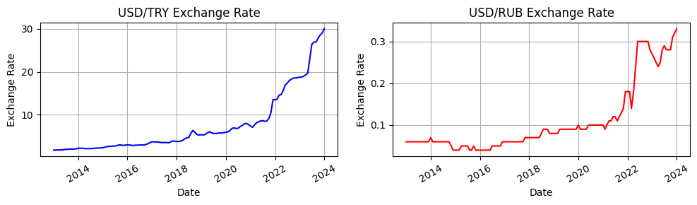

```python
# Comparing USD and RUB data
fig, axes = plt.subplots(nrows=1, ncols=2, figsize=(10, 3))

# 1st subplot
axes[0].plot(df_usd.index, df_usd['TP DK USD A YTL'], label='USD/TRY Exchange Rate', color='blue')
axes[0].set_title('USD/TRY Exchange Rate')
axes[0].set_xlabel('Date')
axes[0].set_ylabel('Exchange Rate')
axes[0].grid(True)

# 2nd subplot
axes[1].plot(df_usd.index, df_usd['TP DK RUB A YTL'], label='USD/RUB Exchange Rate', color='red')
axes[1].set_title('USD/RUB Exchange Rate')
axes[1].set_xlabel('Date')
axes[1].set_ylabel('Exchange Rate')
axes[1].grid(True)

for ax in axes:
    plt.sca(ax)
    plt.xticks(rotation=30)

plt.tight_layout()
plt.show()
```

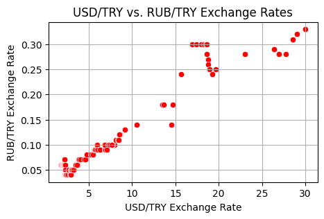

```python
plt.figure(figsize=(5, 3))
sns.scatterplot(x='TP DK USD A YTL', y='TP DK RUB A YTL', data=df_usd, color='red')
plt.title('USD/TRY vs. RUB/TRY Exchange Rates')
plt.xlabel('USD/TRY Exchange Rate')
plt.ylabel('RUB/TRY Exchange Rate')
plt.grid(True)
plt.show()
```

Both in line chart and seasonal plot, RUB/TRY behaves similar to USD/TRY, which again supports the idea that we can use it in our model. In scatter plot, their positive correlation can be seen.

### Linear Regression Model

```
R^2 Score:  0.9219666195674483
Mean Squared Error (MSE): 4.2231292831934555
USD/TRY = -1.2735387060022747 + [78.82783674] * (RUB/TRY)
```

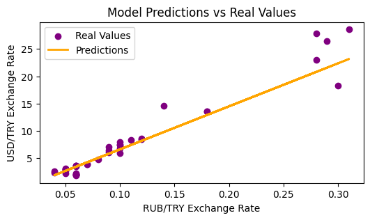

```python
from sklearn.model_selection import train_test_split
from sklearn.linear_model import LinearRegression
from sklearn.metrics import mean_squared_error, r2_score

# indepentent variable
X = df_usd[['TP DK RUB A YTL']].values

# depentent variable
y = df_usd['TP DK USD A YTL'].values

# creating test and train sets
X_train, X_test, y_train, y_test = train_test_split(X, y, test_size=0.3, random_state=0)

# Training the model
model = LinearRegression()
model.fit(X_train, y_train)

# making predictions
y_pred = model.predict(X_test)

# evaluating the model performance
print(f"R^2 Score: ", r2_score(y_test, y_pred))
print("Mean Squared Error (MSE):", mean_squared_error(y_test, y_pred))
print(f"USD/TRY = {model.intercept_} + {model.coef_} * (RUB/TRY) ")

plt.figure(figsize=(6, 3))
plt.scatter(X_test, y_test, color='purple', label='Real Values')
plt.plot(X_test, y_pred, color='orange', linewidth=2, label='Predictions')
plt.title('Model Predictions vs Real Values')
plt.xlabel('RUB/TRY Exchange Rate')
plt.ylabel('USD/TRY Exchange Rate')
plt.legend()
plt.show()
```

```
Residual Mean:  0.5167101746916922
```

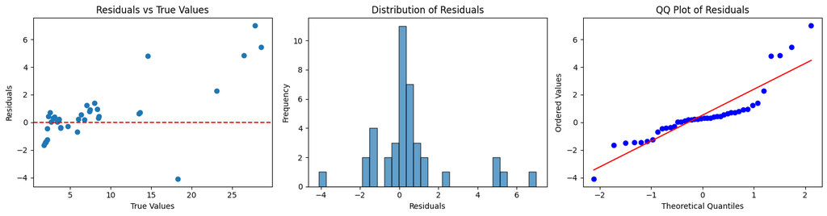

```python
import numpy as np
import scipy.stats as stats

residuals = y_test - y_pred

print(f"Residual Mean: ", np.mean(residuals))

fig, axs = plt.subplots(nrows=1, ncols=3, figsize=(15, 4))

# Residuals vs True Values
axs[0].scatter(y_test, residuals)
axs[0].axhline(y=0, color='r', linestyle='--')
axs[0].set_title('Residuals vs True Values')
axs[0].set_xlabel('True Values')
axs[0].set_ylabel('Residuals')

# Histogram
axs[1].hist(residuals, bins=30, edgecolor='k', alpha=0.7)
axs[1].set_title('Distribution of Residuals')
axs[1].set_xlabel('Residuals')
axs[1].set_ylabel('Frequency')

# QQ Plot
qq = stats.probplot(residuals, dist="norm", plot=axs[2])
axs[2].set_title('QQ Plot of Residuals')
axs[2].set_xlabel('Theoretical Quantiles')
axs[2].set_ylabel('Ordered Values')

plt.tight_layout()
plt.show()
```

In the first graph, most residuals seem to cluster around the zero line, but there is an increase in the size of the residuals as the actual values increase. This may indicate that the model is inadequate for some large values.

The histogram shows that the distribution of the residuals is close to normal, although it does not exactly fit the normal distribution.

The QQ plot shows how well the residuals fit a theoretical normal distribution. Most of the points are close to the baseline; however, there are some deviations at the extremes (especially in the lower left and upper right corners). These deviations show that the residuals, although generally close to the normal distribution, do not exactly fit the normal distribution, confirming our inference from the histogram.

```python
from statsmodels.stats.diagnostic import acorr_ljungbox

# Ljung-Box test
lb_test = acorr_ljungbox(residuals, lags=[10], return_df=True)
print(lb_test)
```

```
     lb_stat  lb_pvalue
10  9.869398   0.452025
```

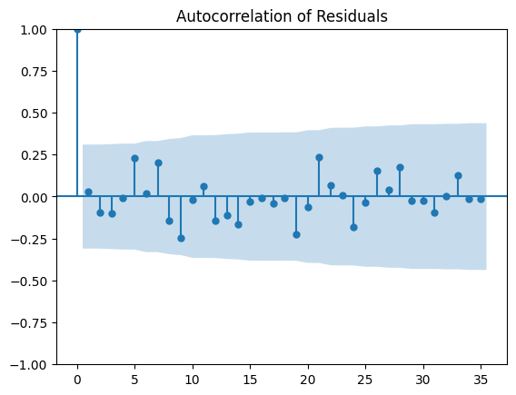

```python
plt.figure(figsize=(6, 3))
plot_acf(residuals, lags=35)
plt.title('Autocorrelation of Residuals')
plt.show()
```

At lag zero, the autocorrelation is always 1 because the series is perfectly correlated with itself regardless of any lag. In the ACF graph, except for the first column (lag 0), all other autocorrelation values fall within the confidence interval. This means that the model residuals do not show significant autocorrelation overall, i.e. they seem to move independently of each other over time.

### 2. LASSO Regression Model

```
R^2 Score:  0.9174021365672829
Mean Squared Error (MSE): 4.470156923336495
USD/TRY = -1.1160013791449321 + [77.38722992] * (RUB/TRY)
```

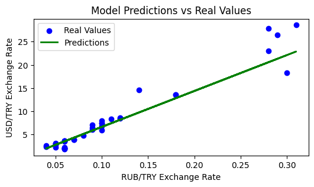

```python
from sklearn.model_selection import train_test_split
from sklearn.linear_model import Lasso
from sklearn.metrics import mean_squared_error

# variables
X = df_usd[['TP DK RUB A YTL']].values
y = df_usd['TP DK USD A YTL'].values

# creating test and train sets
X_train, X_test, y_train, y_test = train_test_split(X, y, test_size=0.3, random_state=0)

# Training the model
lasso_model = Lasso(alpha=0.01, max_iter=10000)
lasso_model.fit(X_train, y_train)

# making predictions
y_pred = lasso_model.predict(X_test)

# evaluating the model performance
print(f"R^2 Score: ", r2_score(y_test, y_pred))
print("Mean Squared Error (MSE):", mean_squared_error(y_test, y_pred))
print(f"USD/TRY = {lasso_model.intercept_} + {lasso_model.coef_} * (RUB/TRY) ")

plt.figure(figsize=(6, 3))
plt.scatter(X_test, y_test, color='blue', label='Real Values')
plt.plot(X_test, y_pred, color='green', linewidth=2, label='Predictions')
plt.title('Model Predictions vs Real Values')
plt.xlabel('RUB/TRY Exchange Rate')
plt.ylabel('USD/TRY Exchange Rate')
plt.legend()
plt.show()
```

```
Residual Mean:  0.5133177779776545
```

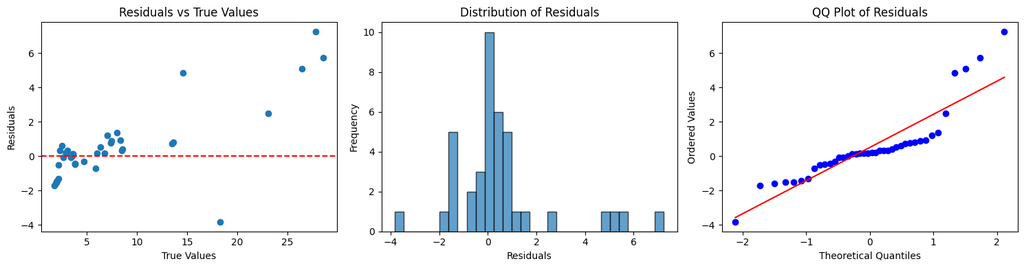

```python
residuals_lasso = y_test - y_pred

print(f"Residual Mean: ", np.mean(residuals_lasso))

fig, axs = plt.subplots(nrows=1, ncols=3, figsize=(15, 4))

# Residuals vs True Values
axs[0].scatter(y_test, residuals_lasso)
axs[0].axhline(y=0, color='r', linestyle='--')
axs[0].set_title('Residuals vs True Values')
axs[0].set_xlabel('True Values')
axs[0].set_ylabel('Residuals')

# Histogram
axs[1].hist(residuals_lasso, bins=30, edgecolor='k', alpha=0.7)
axs[1].set_title('Distribution of Residuals')
axs[1].set_xlabel('Residuals')
axs[1].set_ylabel('Frequency')

# QQ Plot
qq = stats.probplot(residuals_lasso, dist="norm", plot=axs[2])
axs[2].set_title('QQ Plot of Residuals')
axs[2].set_xlabel('Theoretical Quantiles')
axs[2].set_ylabel('Ordered Values')

plt.tight_layout()
plt.show()
```

```python
from statsmodels.stats.diagnostic import acorr_ljungbox

# Ljung-Box test
lb_test = acorr_ljungbox(residuals_lasso, lags=[10], return_df=True)
print(lb_test)
```

```
      lb_stat  lb_pvalue
10  10.208135   0.422427
```

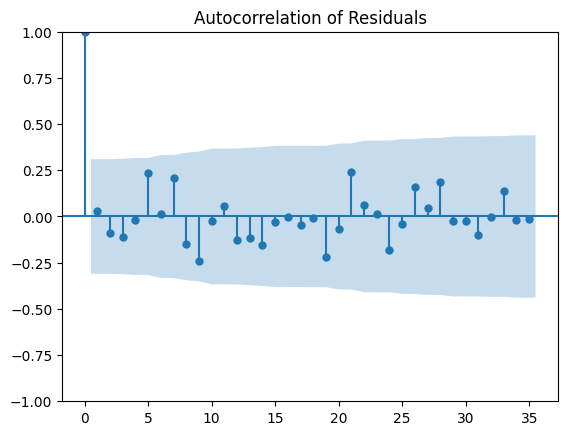

```python
plt.figure(figsize=(6, 3))
plot_acf(residuals_lasso, lags=35)
plt.title('Autocorrelation of Residuals')
plt.show()
```

### 3. Log Transform Model

```
R^2 Score:  0.9141139694275534
Mean Squared Error (MSE): 56.5001193381933
USD/TRY = 4.533689683054115 + [1.18198858] * (RUB/TRY)
```

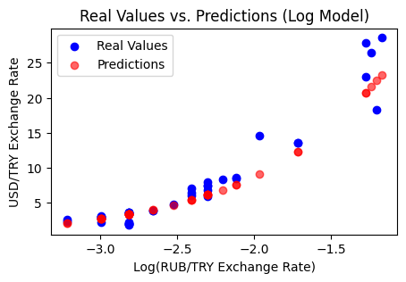

```python
df_usd['TP DK RUB A YTL_log'] = np.log(df_usd['TP DK RUB A YTL'])
df_usd['TP DK USD A YTL_log'] = np.log(df_usd['TP DK USD A YTL'])

# variables
X = df_usd[['TP DK RUB A YTL_log']].values.reshape(-1, 1) # Log transformed
y = df_usd['TP DK USD A YTL_log'].values # Log transformed

# creating test and train sets
X_train, X_test, y_train, y_test = train_test_split(X, y, test_size=0.3, random_state=0)

# Training the model
model_log = LinearRegression()
model_log.fit(X_train, y_train)

# Making predictions
y_pred_log = model_log.predict(X_test)

# Convert estimates to original scale
y_pred = np.exp(y_pred_log)
y_test_exp = np.exp(y_test)

# evaluating the model performance
print(f"R^2 Score: ", r2_score(y_test_exp, y_pred))
print("Mean Squared Error (MSE):", mean_squared_error(y_test, y_pred))
print(f"USD/TRY = {model_log.intercept_} + {model_log.coef_} * (RUB/TRY) ")

# visuals
plt.figure(figsize=(5, 3))
plt.scatter(X_test, y_test_exp, color='blue', label='Real Values')
plt.scatter(X_test, y_pred, color='red', label='Predictions', alpha=0.6)
plt.title('Real Values vs. Predictions (Log Model)')
plt.xlabel('Log(RUB/TRY Exchange Rate)')
plt.ylabel('USD/TRY Exchange Rate')
plt.legend()
plt.show()
```

### Result

We can say that the latest model is no better than the first and second models among the models with non-linearized data. So, in the end, we can make our choice in favor of the first model, which is the simplest model.

Since there is only one independent variable, the success of the model depends on it, without it the model is meaningless. So we can call the coefficient of this variable significant.

If we compare ARIMA(0,1,2), the most successful ARIMA model, with Linear Regression with non-stationarized data, we can say that both models are successful and can have their own advantages and usage scenarios.